# Minimal CV

Luisa Maria Mimmi

09 September, 2017

# Contacts

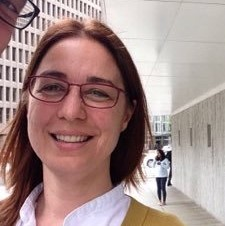

Me

[linkedin](https://www.linkedin.com/in/luisa-m-mimmi/)

[github](https://github.com/Lulander)

# Employment

*WORLD BANK* Monitoring & Evaluation Officer - Water and Urban Development (Washington, DC, USA) 2009-2017

*IADB* Policy Analyst – Entrepreneurship and vocational training (Washington, DC, USA) 2008-2009

*AVSI-CDM* Summer Intern – Slum Upgrading and Social Inclusion (Rio de Janeiro & Belo Horizonte, BRAZIL) 2007

*VALUE PARTNERS S.p.A.* Business Intelligence Analyst (Milano, ITALY) 2001-2006

# Education

*Shool of Public Policy, GEORGETOWN UNIVERSITY*, M.P.P. 2008

*UNIVERSITÀ DEGLI STUDI DI PAVIA* , B.A. Economics 2001

# Publications

## Journal Articles

Luisa M. Mimmi. 2014. *From informal to authorized electricity service in urban slums: Findings from a household level survey in Mumbai*. Energy for Sustainable Development, Vol. 21, pages 66–80.

Luisa M. Mimmi, Sencer Ecer. 2010. *An econometric study of illegal electricity connections in the urban favelas of Belo Horizonte, Brazil*. Energy Policy, Vol. 38(9), pages 5081–5097.

## Other Publications

Rodriguez, Diego J.; Suardi, Mario A.; Ham, Marcel; Mimmi, Luisa M.; Goksu, Amanda J.. 2014. *Applying results-based financing in water investments*. Water partnership program (WPP); Water papers. Washington DC, World Bank.

Luisa M. Mimmi. 2012. *Should we re-evaluate what to evaluate (and how)?* GPOBA evaluation notes; no. 1. Washington DC, World Bank.

Luisa M. Mimmi. 2009. *Youth Employment and Entrepreneurship Programs: A Review of Eight Best Practices*. Policy Working Paper. Washington DC, Social Protection and Health Division, IADB.

# References

Available upon request.